# V-Dem Data

Start by loading the tidyverse:

```r
library(tidyverse)
```

The V-Dem project uses surveys of area experts to measure democracy and quality of governance along multiple dimensions over time and across countries. Their core data set also includes a number of additional measures of country characteristics from other sources like GDP, oil production and literacy.

If you’re interested in comparing political structures across countries or a long period of time, this is a good starting point. Take a look at [their codebook](https://www.v-dem.net/documents/38/V-Dem_Codebook_v14.pdf) to get a sense of what is available, [check here](https://www.v-dem.net/documents/39/v-dem_methodology_v14.pdf) for an in-depth discussion of their methodology [or look here](https://www.v-dem.net/graphing/graphing-tools/) for some online tools that will let you explore their data.

# Bringing in the V-DEM data

We can download the entire data set from their website in .csv, but there’s also an R-package that allows you to download and import the latest version of the V-Dem data from within R.

The `vdemdata` package is hosted on a github site, so the installation process is a little different from what we normally do. We first need to install `devtools`

```r
install.packages("devtools")
```

Then we can install the vdem data package with this command:

```r
devtools::install_github("vdeminstitute/vdemdata")
```

Once you’ve installed the package, you can import the VDEM data like this:

```r
vdem<-vdemdata::vdem
```

Take a minute to examine some of the variables and the [codebook](https://www.v-dem.net/static/website/img/refs/codebookv111.pdf), identify the unit of analysis, and try to get a sense of what sorts of options are available for thinking about the nature of a country’s government.

## Plotting recent democracy scores

VDEM has what we would call “cross sectional time series” data: it contains data on multiple countries over multiple years. This can be helpful if we’re trying to look at a relationship over time, but in some cases we might just be interested in the most recent data. VDEM actually has coverage through 2023, but we’re going to pull 2018 here instead because some of the variables only go through that date:

```r
vdem_recent<-vdem|>
  filter(year == 2018)
```

## Plotting democracy scores

`v2x_libdem` is one of the five-dimensions of democracy measured by V-DEM. Its a continuous variable that ranges from 0 to 1.

Histograms, density plots and box plots are good ways to visualize a continuous variable. And the code for all three of these is pretty intuitive:

**Histogram**

A histogram separates the continuous variable into “bins” and then counts the frequency within each bin.

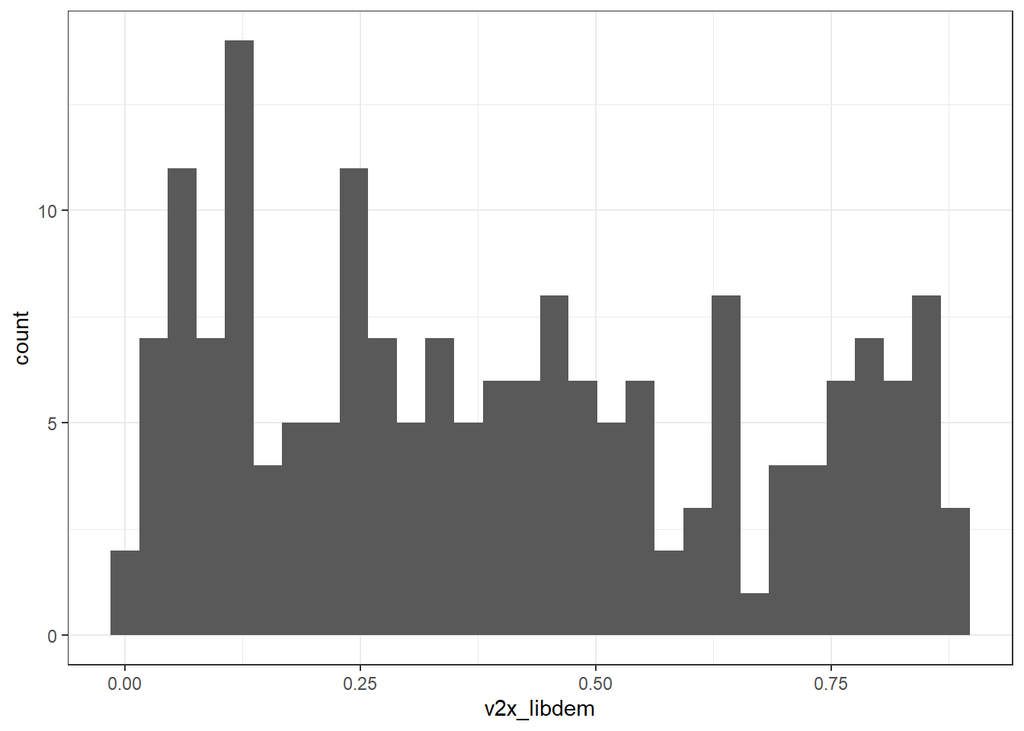

```r
ggplot(vdem_recent, aes(x=v2x_libdem)) +
  geom_histogram() +
  theme_bw()
```

**Density plot**

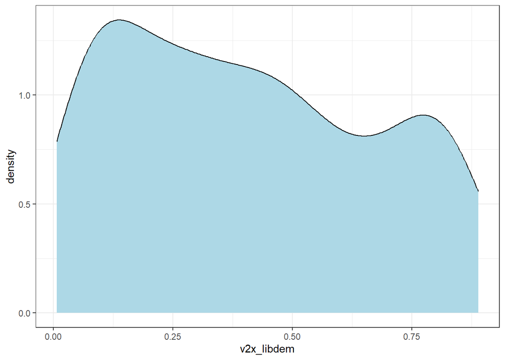

```r
ggplot(vdem_recent, aes(x=v2x_libdem)) +
  # add a fill here to make this a bit more legible
  geom_density(fill='lightblue') +
  theme_bw()
```

**Boxplot**

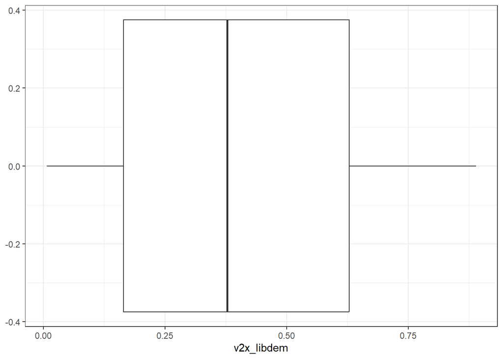

```r
ggplot(vdem_recent, aes(x=v2x_libdem)) +
  geom_boxplot() +
  theme_bw()
```

## Bar plot of democracy

We can use another bar plot to look at one of the democracy score variables in this dataset. We’ll also use the `reorder` function to sort the countries from the highest democracy score to the lowest:

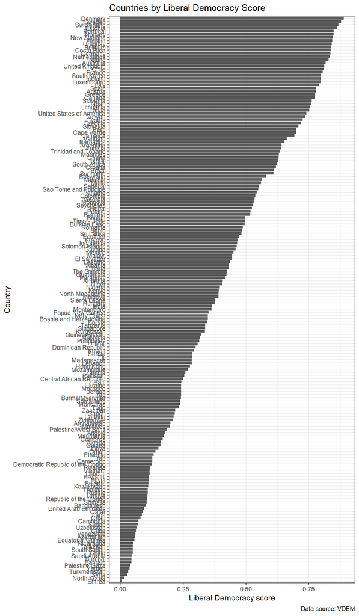

```r
ggplot(vdem_recent, aes(x=reorder(country_name, v2x_libdem), y=v2x_libdem)) +
  geom_bar(stat='identity')+
  coord_flip() +
  theme_bw() +
  ylab('Liberal Democracy score') +
  xlab("Country") +
  labs(title = "Countries by Liberal Democracy Score",
              caption = "Data source: VDEM")
```

## Democracy and GDP

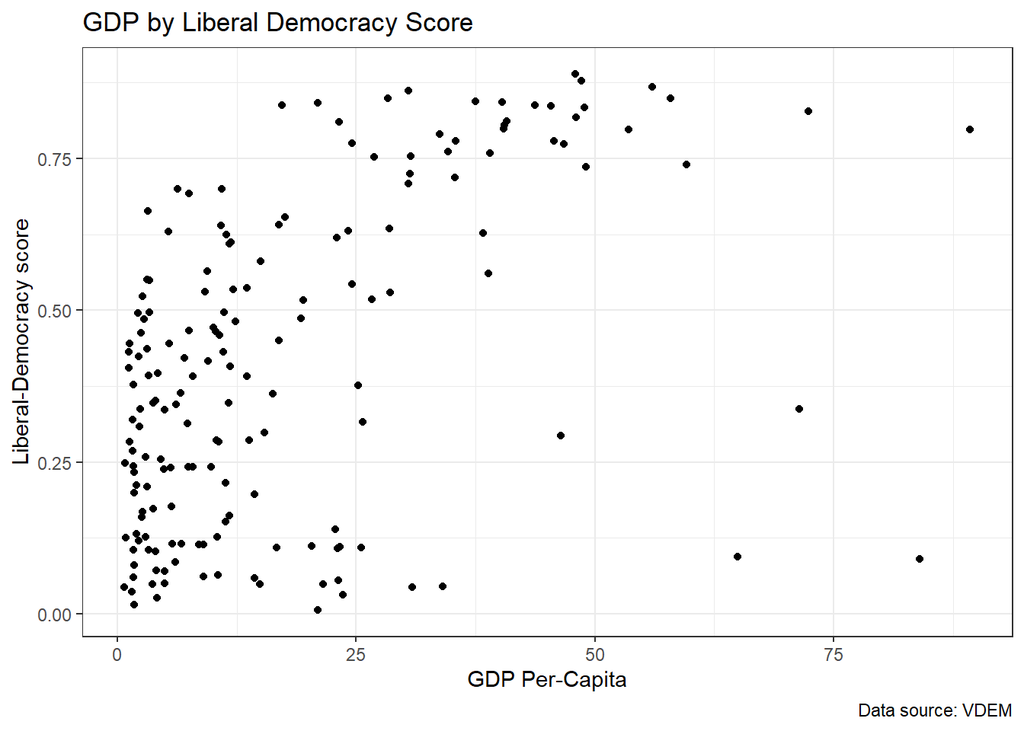

```r
ggplot(vdem_recent, aes(x=e_gdppc, y=v2x_libdem)) +
  geom_point() +
  theme_bw() +
  xlab('GDP Per-Capita') +
  ylab("Liberal-Democracy score") +
  labs(title = "GDP by Liberal Democracy Score",
              caption = "Data source: VDEM")
```

## Question

`e_peaveduc` represents the “average years of education among citizens older than 15”. Make a plot that shows the relationship between educational attainment and the level of democracy. Does it look different from the relationship with GDP?

```r
# scatter plot of educational attainment vs democracy score
```

# Combining data sets

Can we see a relationship between protest or violence and the characteristics of a state? We’ll talk more about this in a later class, but we can start thinking about how we would need to approach this for a good analysis.

Consider how you might use this data to look at the relationship between protest activity or state repression and regime type. What would we need to do to combine these two data sets into one?